# R Notebook - Violência contra a mulher (2019)

Foi considerada violência física de pessoas do sexo feminino de 18 anos ou mais de idade que informaram terem sofrido violência física nos últimos 12 meses (Mil pessoas).  
Fonte: IBGE - Pesquisa Nacional de Saúde (Microdados da PNS de 2019) https://www.ipea.gov.br/atlasviolencia/dados-series/270. Autor: Giseldo da Silva Neo Email: giseldo@gmail.com

| cod | nome | periodo | valor |
| --- | --- | --- | --- |
| 27 | AL | 2019 | 41 |
| 16 | AP | 2019 | 12 |
| 13 | AM | 2019 | 67 |
| 29 | BA | 2019 | 365 |
| 23 | CE | 2019 | 157 |
| 53 | DF | 2019 | 50 |

```r
summary (df$valor)
```

```
   Min. 1st Qu.  Median    Mean 3rd Qu.    Max.
   10.0    40.0    67.0   132.7   168.5   817.0
```

A menor quantidade de crime contra a mulher em 2019 foi de 10 mil. A maior 817 mil. Em média, por estado em 2019, foram 132 mil crimes contra a mulher.

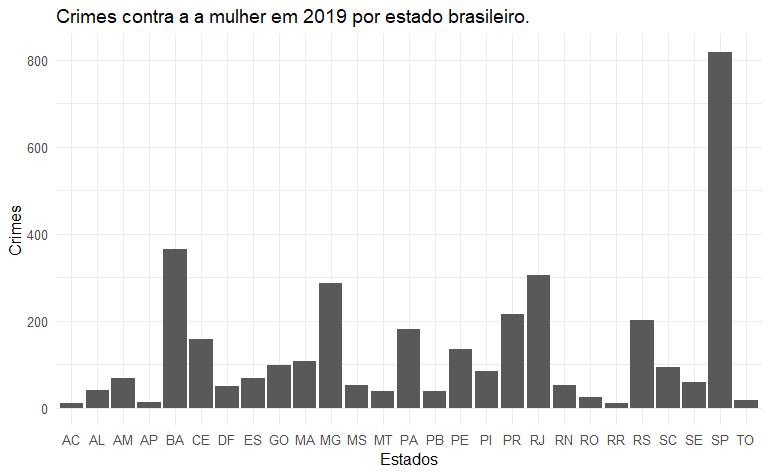

```r
df = read_csv('violencia.csv')
ggplot(data=df) +
  geom_col(mapping = aes(x=nome, y=valor)) +
  xlab(label="Estados") +
  ylab(label="Crimes") +
  labs(title = "Crimes contra a a mulher em 2019 por estado brasileiro.") +
  theme_minimal()
```

Conforme os dados, os crimes contra a mulher em 2019 no estado de São Paulo foram maiores do que em outros estados. Só em são Paulo, foram 800 mil mulheres vítimas de violência.

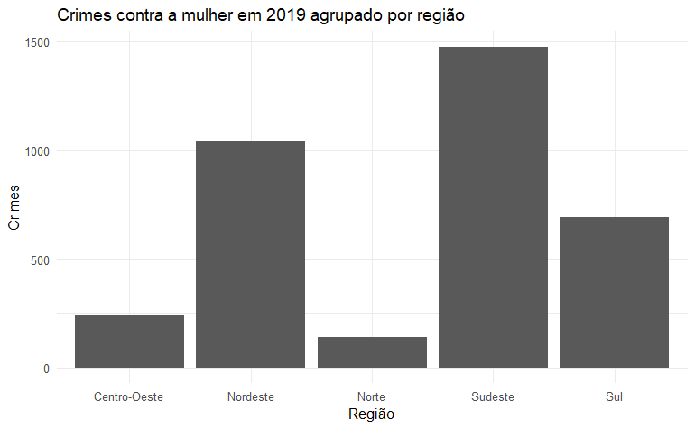

```r
df["regiao"] <- c("Nordeste", "Norte", "Norte", "Nordeste", "Nordeste", "Centro-Oeste", "Sudeste", "Centro-Oeste", "Nordeste","Centro-Oeste", "Centro-Oeste", "Sudeste", "Sul", "Nordeste", "Sul", "Nordeste", "Nordeste", "Sudeste", "Nordeste", "Sul", "Norte", "Sul", "Sudeste", "Nordeste", "Norte", "Norte", "Norte")

df_grp_regiao = df %>% group_by(regiao) %>%
  summarise(crimes=sum(valor))

ggplot(data=df_grp_regiao, aes(x=regiao, y=crimes)) +
  geom_col() +
  xlab("Região") +
  ylab("Crimes") +
  labs(
    title = "Crimes contra a mulher em 2019 agrupado por região"
  ) +
  theme_minimal()
```

Conforme dados a região brasileira que teve a maior quantidade de crimes contra a mulher em 2019 foi a região sudeste.

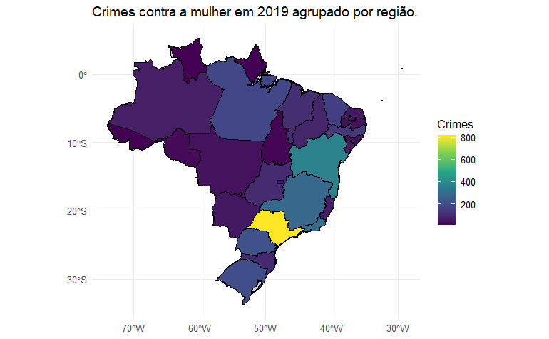

Conforme os dados são paulo, na região sudeste e na região ao redor de São Paulo, foram os estados com mais violência contra a mulher em 2019. Já a Região norte a menor quantidade de crimes.